# LSOCV-v4-reviewer-comments-28-07-26

# Introduction

This file goes over the updated feature selection and metrics based on the bootstrap at the parent level. The results presented here are based on LSOCV with no information leakage (separate feature selection across 10 folds).

# Feature selection with updated bootstrap

## Filter at 0.05 (rowSums(count >= 5) >= 0.05)

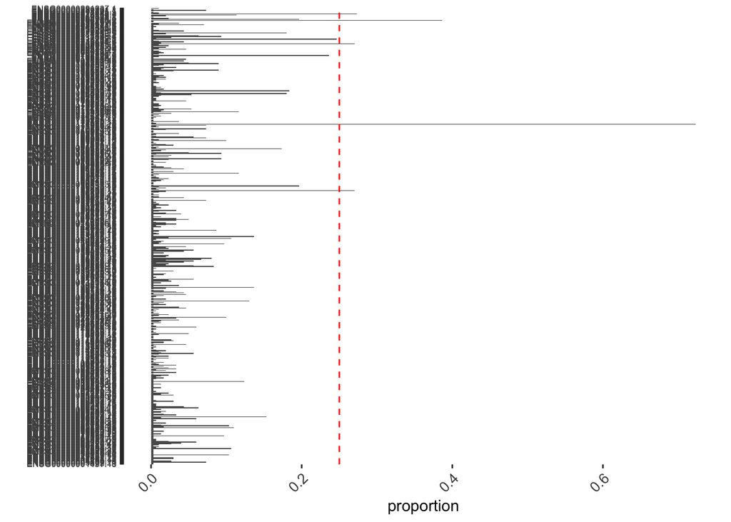

Selected features are: ENSG00000157500.12, ENSG00000171988.20, ENSG00000206585.1, ENSG00000263740.2, ENSG00000276168.1

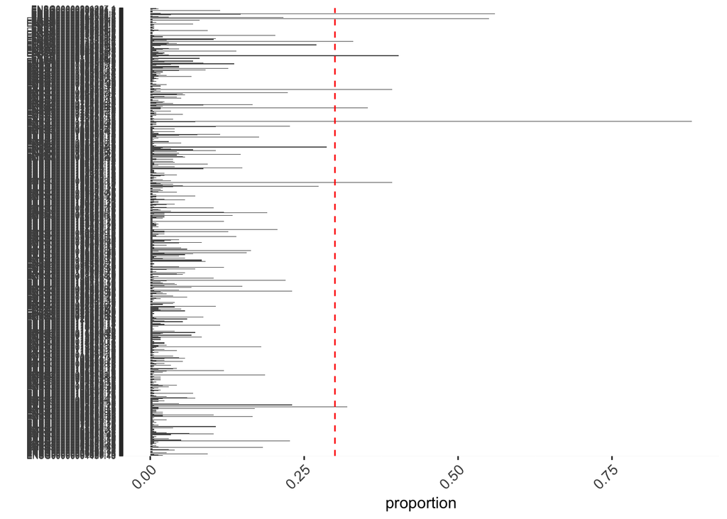

Selected features are: ENSG00000090621.15, ENSG00000159352.16, ENSG00000171988.20, ENSG00000175416.16, ENSG00000184990.13, ENSG00000198899.2, ENSG00000213707.2, ENSG00000263740.2, ENSG00000276168.1

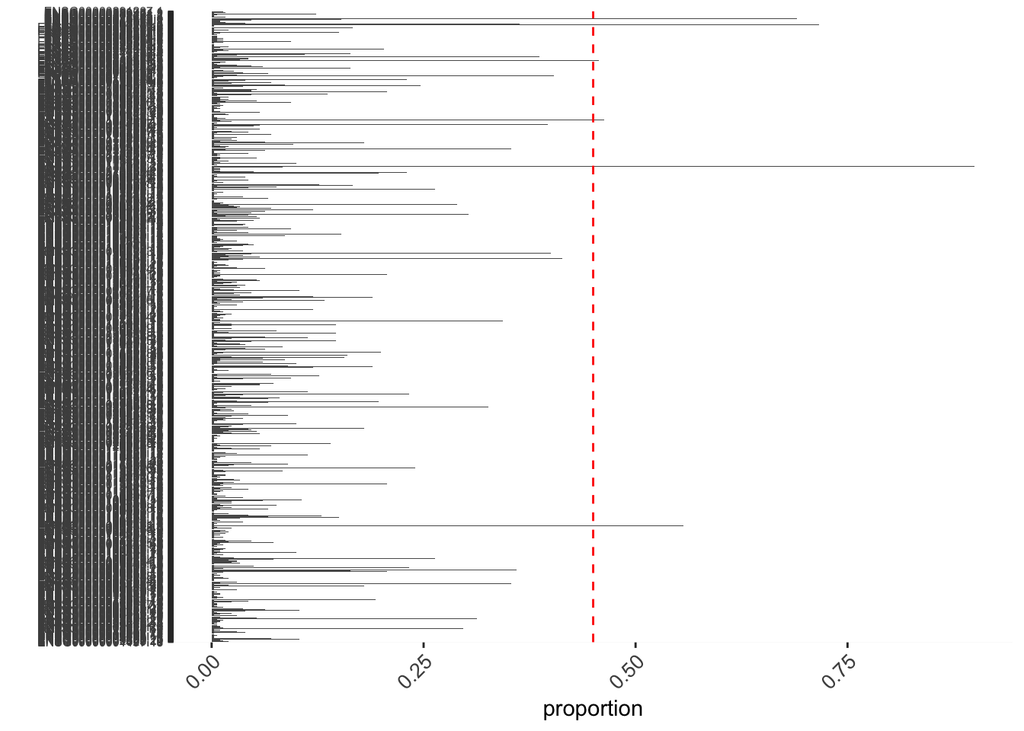

Selected features are: ENSG00000105372.8, ENSG00000171988.20, ENSG00000184990.13, ENSG00000206585.1, ENSG00000263740.2, ENSG00000276168.1

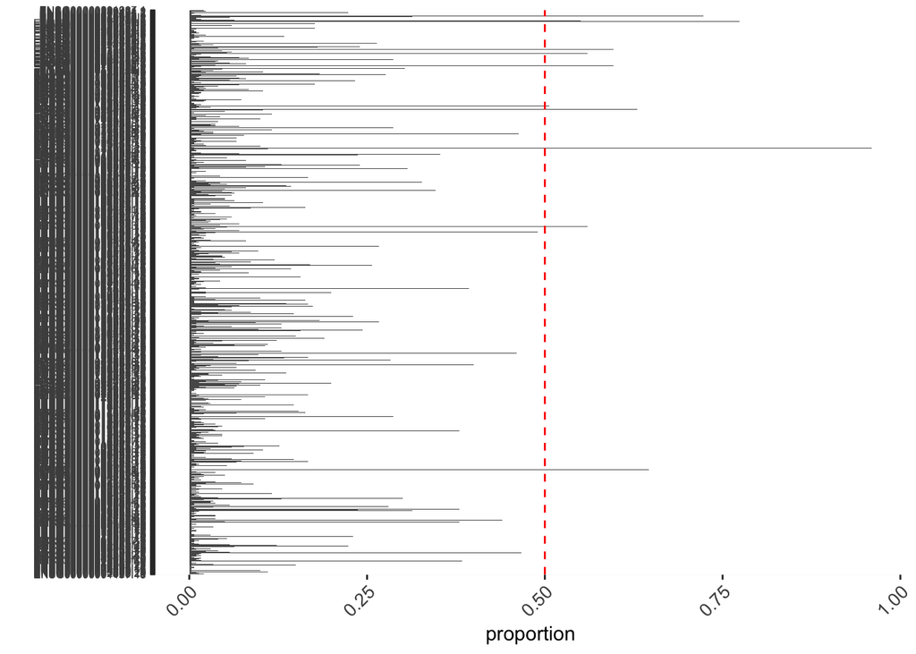

Selected features are: ENSG00000105372.8, ENSG00000159352.16, ENSG00000171988.20, ENSG00000184357.5, ENSG00000184990.13, ENSG00000198899.2, ENSG00000206585.1, ENSG00000213707.2, ENSG00000263740.2, ENSG00000264229.1, ENSG00000276168.1

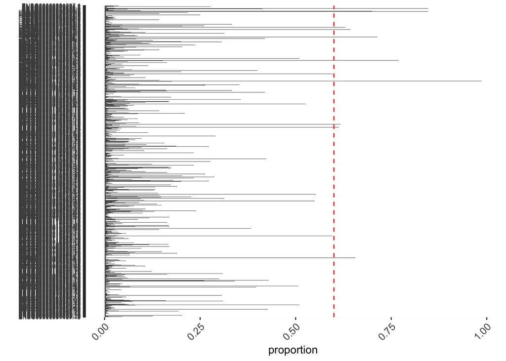

Selected features are: ENSG00000105372.8, ENSG00000157500.12, ENSG00000159352.16, ENSG00000171988.20, ENSG00000184357.5, ENSG00000198899.2, ENSG00000206585.1, ENSG00000213707.2, ENSG00000263740.2, ENSG00000264229.1, ENSG00000276168.1

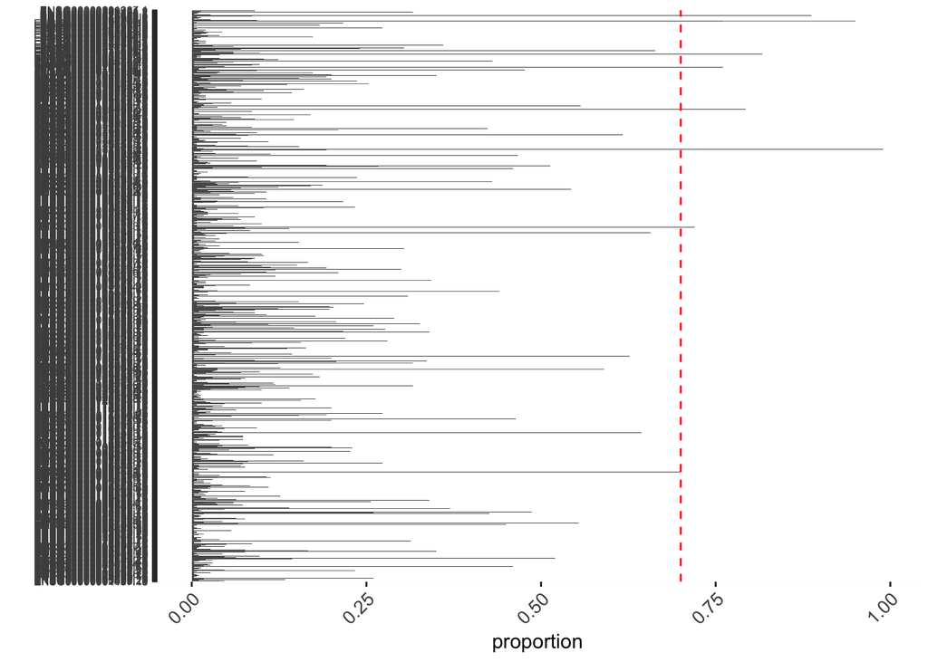

Selected features are: ENSG00000105372.8, ENSG00000159352.16, ENSG00000171988.20, ENSG00000184357.5, ENSG00000198899.2, ENSG00000206585.1, ENSG00000263740.2, ENSG00000264229.1, ENSG00000276168.1

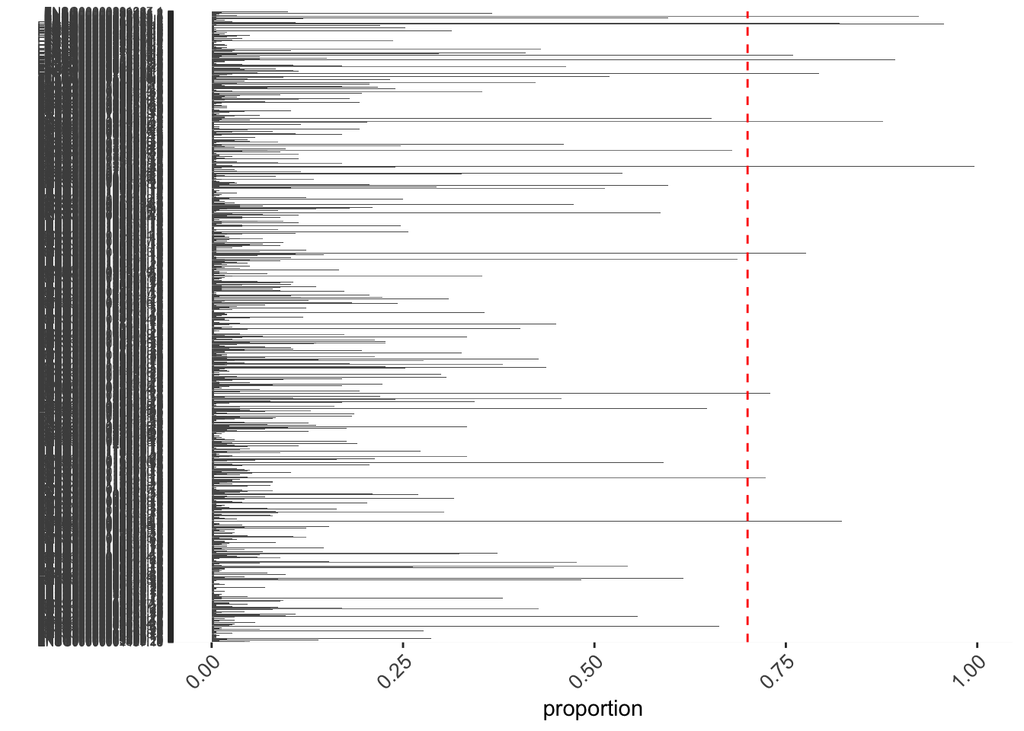

Selected features are: ENSG00000105372.8, ENSG00000113643.9, ENSG00000130772.14, ENSG00000159352.16, ENSG00000171988.20, ENSG00000184357.5, ENSG00000198899.2, ENSG00000206585.1, ENSG00000213707.2, ENSG00000263740.2, ENSG00000264229.1, ENSG00000276168.1

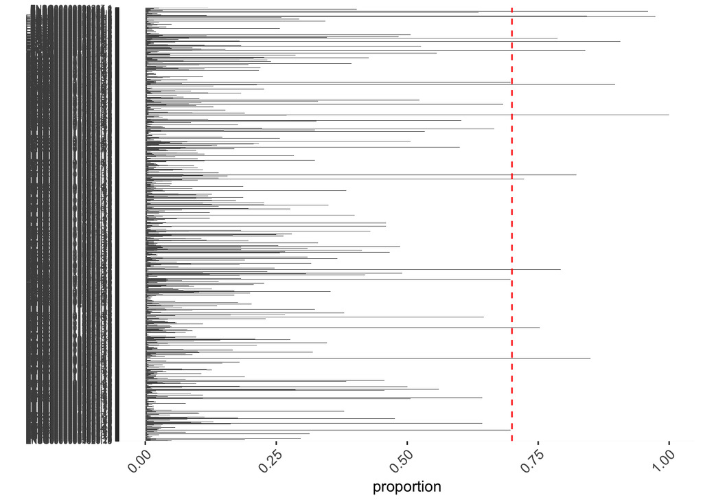

Selected features are: ENSG00000105372.8, ENSG00000113643.9, ENSG00000130772.14, ENSG00000157500.12, ENSG00000159352.16, ENSG00000171988.20, ENSG00000184357.5, ENSG00000198899.2, ENSG00000206585.1, ENSG00000213707.2, ENSG00000263740.2, ENSG00000264229.1, ENSG00000276168.1

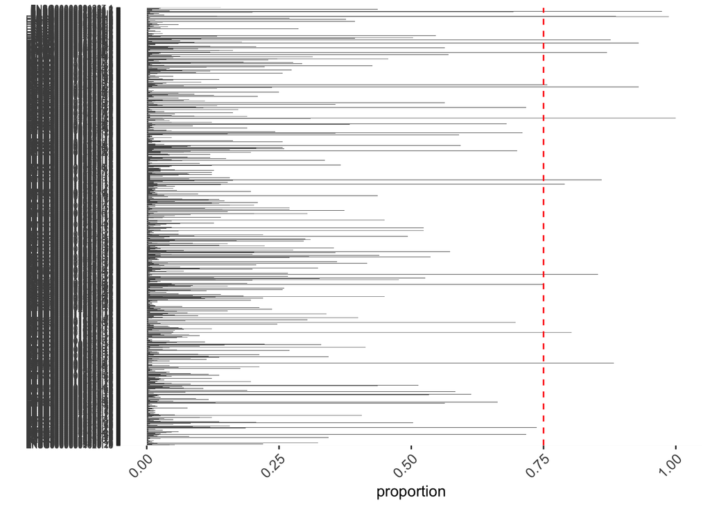

Selected features are: ENSG00000105372.8, ENSG00000113643.9, ENSG00000127603.32, ENSG00000130772.14, ENSG00000157500.12, ENSG00000159352.16, ENSG00000171988.20, ENSG00000184357.5, ENSG00000184990.13, ENSG00000198899.2, ENSG00000206585.1, ENSG00000213707.2, ENSG00000263740.2, ENSG00000264229.1, ENSG00000276168.1

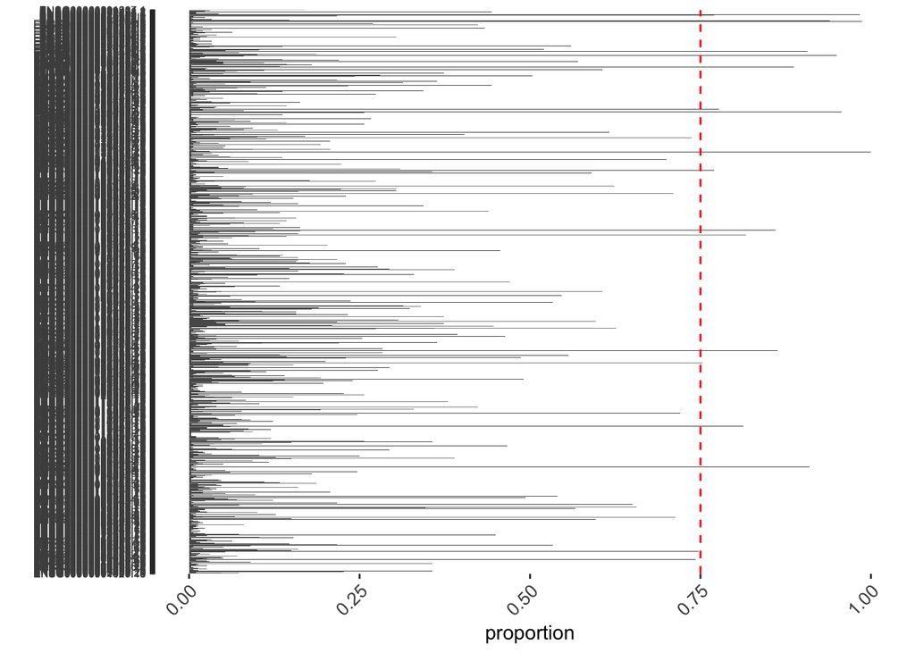

Selected features are: ENSG00000105372.8, ENSG00000113643.9, ENSG00000127603.32, ENSG00000130772.14, ENSG00000157500.12, ENSG00000159352.16, ENSG00000168092.14, ENSG00000171988.20, ENSG00000184357.5, ENSG00000184990.13, ENSG00000198899.2, ENSG00000206585.1, ENSG00000213707.2, ENSG00000263740.2, ENSG00000264229.1, ENSG00000275110.1, ENSG00000276168.1

## Filter at 0.1 (rowSums(count >= 5) >= 0.1)

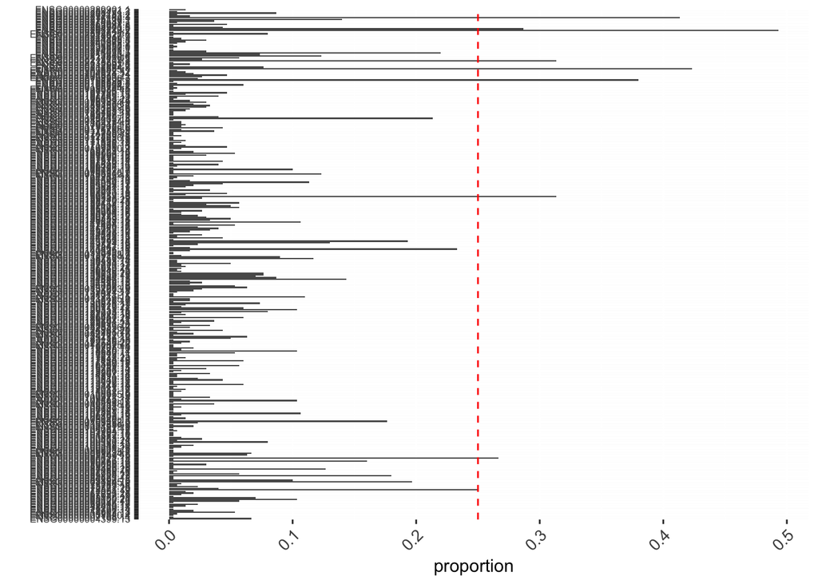

Selected features are: ENSG00000072501.19, ENSG00000090621.15, ENSG00000159352.16, ENSG00000198899.2, ENSG00000206585.1, ENSG00000213707.2, ENSG00000263740.2, ENSG00000264229.1, ENSG00000276168.1

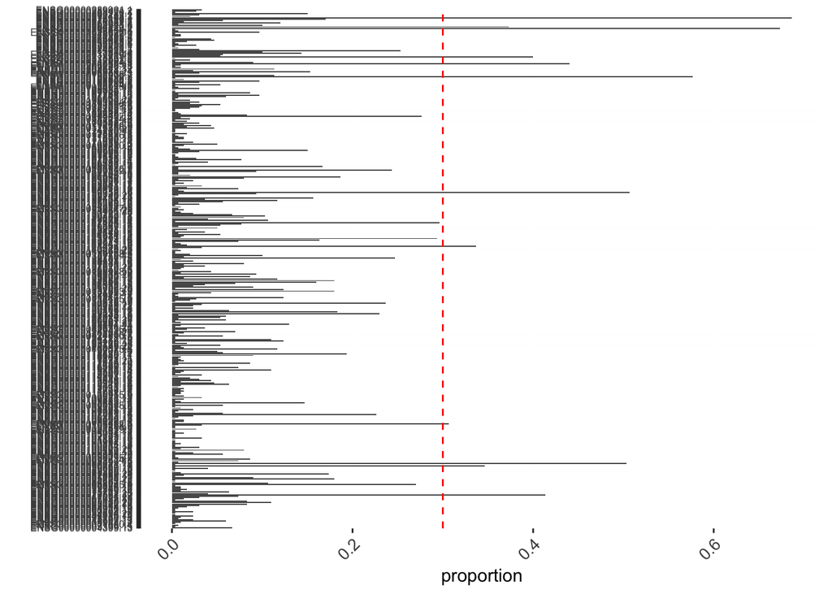

Selected features are: ENSG00000072501.19, ENSG00000090266.13, ENSG00000090621.15, ENSG00000105372.8, ENSG00000141456.16, ENSG00000159352.16, ENSG00000198899.2, ENSG00000206585.1, ENSG00000213707.2, ENSG00000263740.2, ENSG00000264229.1, ENSG00000276168.1

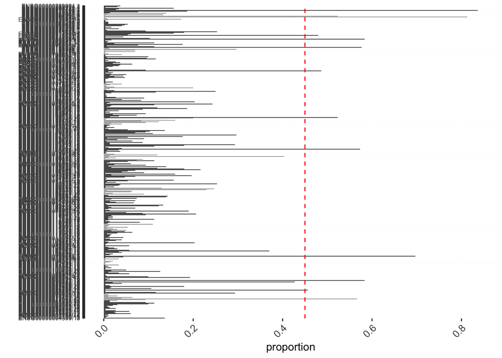

Selected features are: ENSG00000072501.19, ENSG00000085224.23, ENSG00000090621.15, ENSG00000105372.8, ENSG00000141456.16, ENSG00000159352.16, ENSG00000184357.5, ENSG00000198899.2, ENSG00000206585.1, ENSG00000213707.2, ENSG00000263740.2, ENSG00000264229.1, ENSG00000276168.1

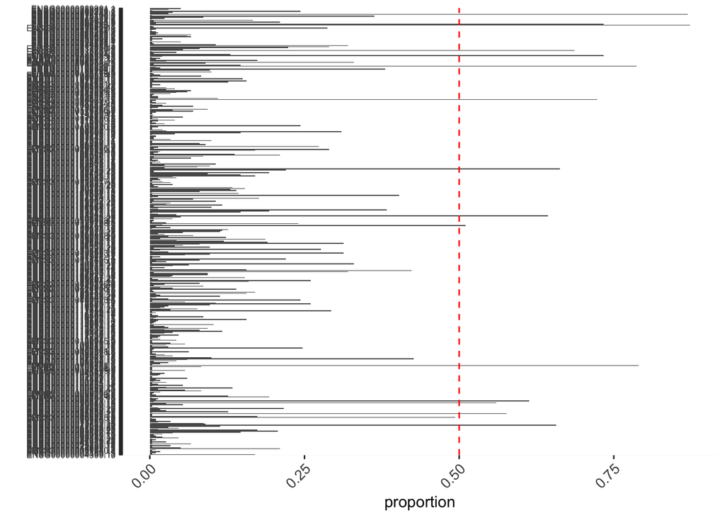

Selected features are: ENSG00000072501.19, ENSG00000085224.23, ENSG00000090266.13, ENSG00000090621.15, ENSG00000105372.8, ENSG00000138757.15, ENSG00000141456.16, ENSG00000159352.16, ENSG00000184357.5, ENSG00000198899.2, ENSG00000206585.1, ENSG00000213707.2, ENSG00000263740.2, ENSG00000264229.1, ENSG00000276168.1

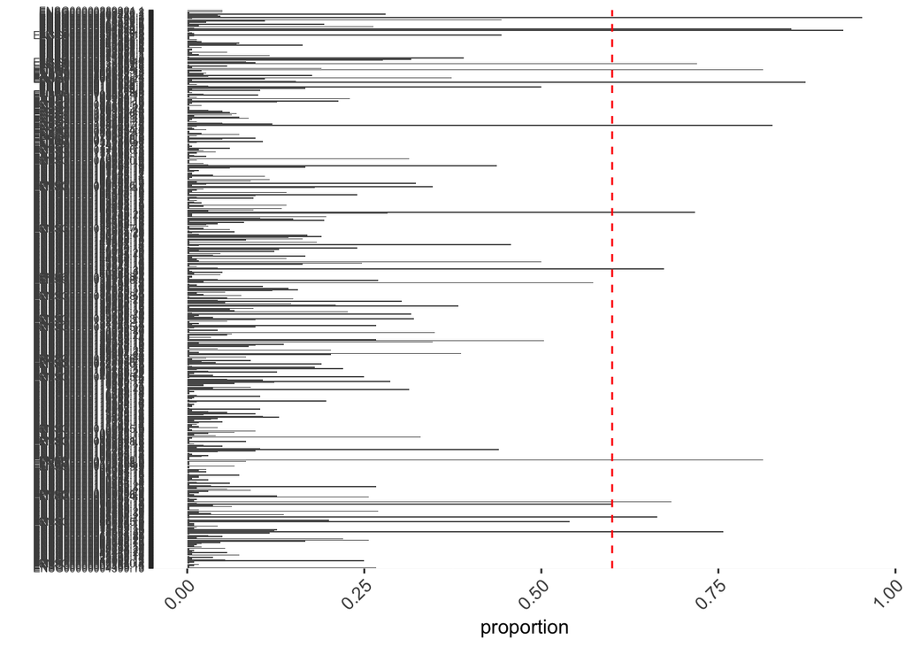

Selected features are: ENSG00000072501.19, ENSG00000085224.23, ENSG00000090266.13, ENSG00000090621.15, ENSG00000105372.8, ENSG00000141456.16, ENSG00000159352.16, ENSG00000184357.5, ENSG00000198899.2, ENSG00000206585.1, ENSG00000213707.2, ENSG00000263740.2, ENSG00000264229.1, ENSG00000276168.1

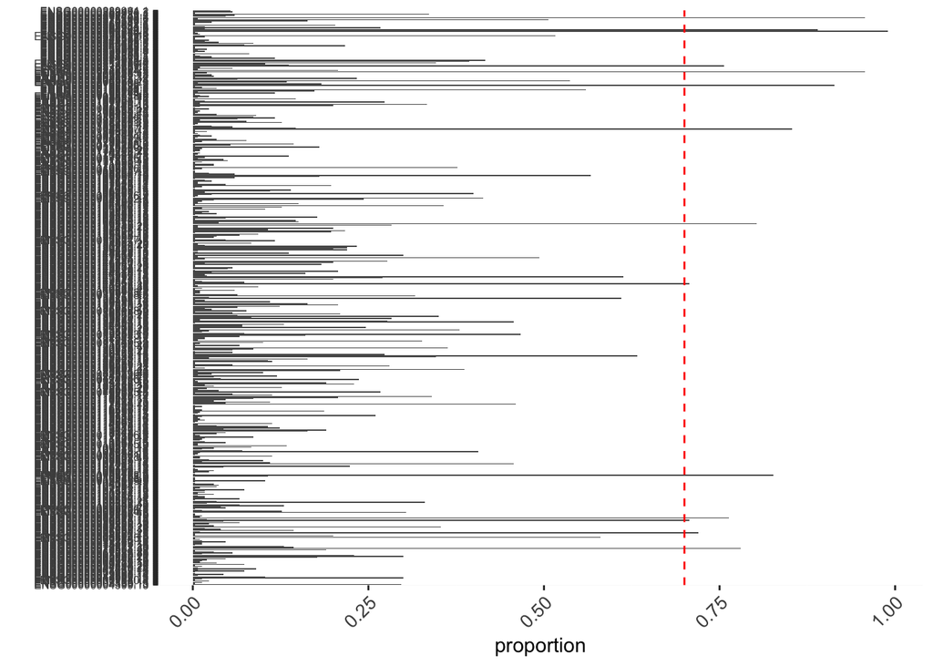

Selected features are: ENSG00000072501.19, ENSG00000085224.23, ENSG00000090266.13, ENSG00000090621.15, ENSG00000105372.8, ENSG00000141456.16, ENSG00000159352.16, ENSG00000184357.5, ENSG00000198899.2, ENSG00000206585.1, ENSG00000213707.2, ENSG00000263740.2, ENSG00000264229.1, ENSG00000276168.1

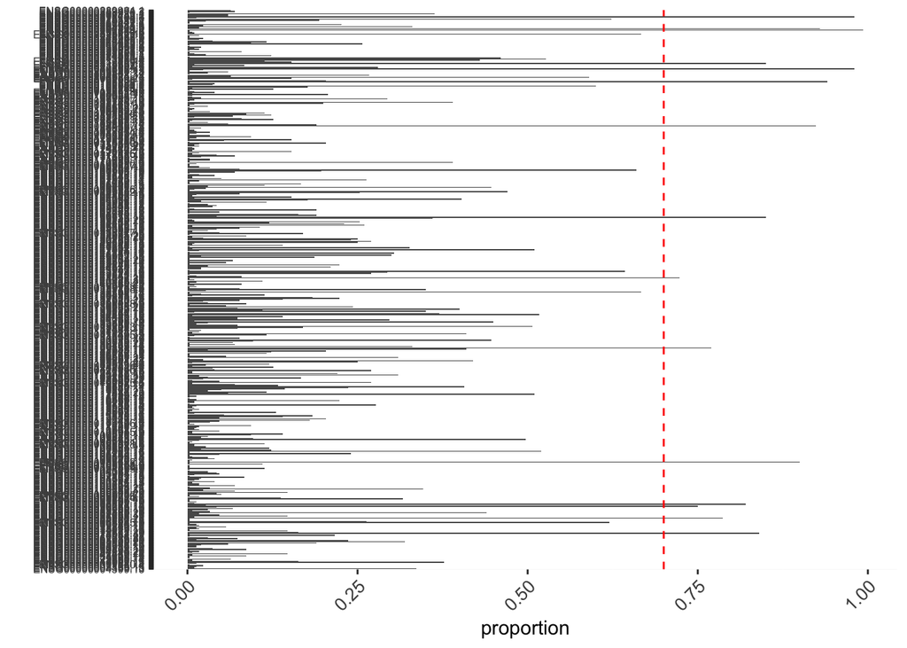

Selected features are: ENSG00000072501.19, ENSG00000085224.23, ENSG00000090266.13, ENSG00000090621.15, ENSG00000105372.8, ENSG00000129351.18, ENSG00000141456.16, ENSG00000159352.16, ENSG00000184357.5, ENSG00000198899.2, ENSG00000206585.1, ENSG00000213707.2, ENSG00000263740.2, ENSG00000264229.1, ENSG00000276168.1

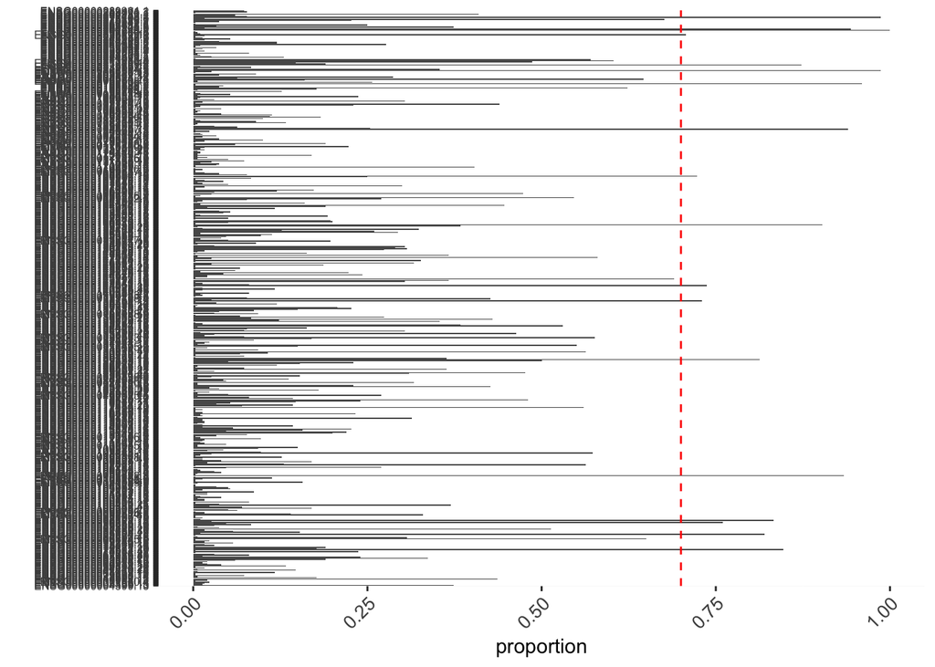

Selected features are: ENSG00000072501.19, ENSG00000085224.23, ENSG00000090266.13, ENSG00000090621.15, ENSG00000105372.8, ENSG00000129351.18, ENSG00000138757.15, ENSG00000141456.16, ENSG00000159352.16, ENSG00000168003.19, ENSG00000184357.5, ENSG00000198899.2, ENSG00000206585.1, ENSG00000213707.2, ENSG00000251562.11, ENSG00000263740.2, ENSG00000264229.1, ENSG00000276168.1

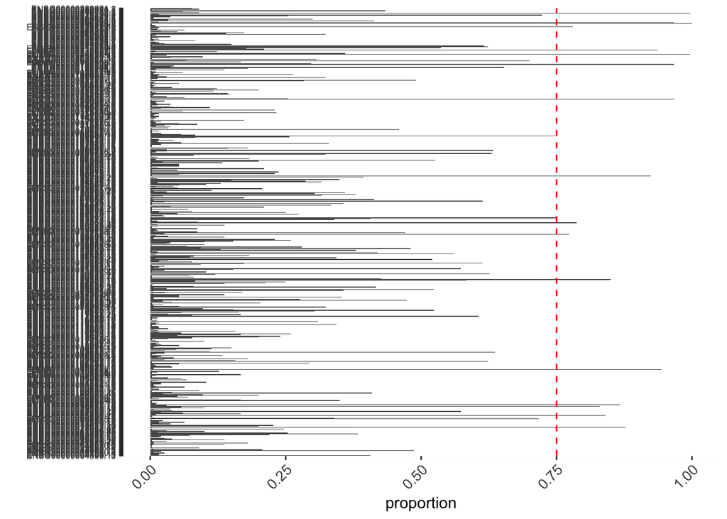

Selected features are: ENSG00000072501.19, ENSG00000085224.23, ENSG00000090266.13, ENSG00000090621.15, ENSG00000105372.8, ENSG00000129351.18, ENSG00000138757.15, ENSG00000141456.16, ENSG00000143799.14, ENSG00000159352.16, ENSG00000184357.5, ENSG00000198899.2, ENSG00000206585.1, ENSG00000213707.2, ENSG00000251562.11, ENSG00000263740.2, ENSG00000264229.1, ENSG00000276168.1

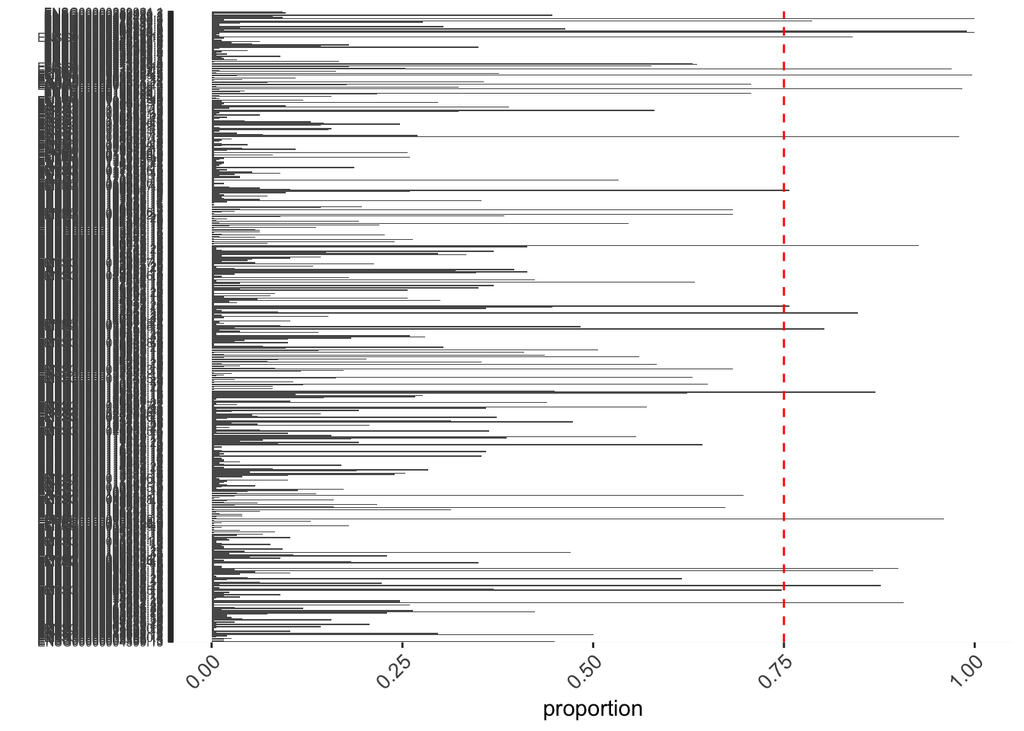

Selected features are: ENSG00000072501.19, ENSG00000085224.23, ENSG00000090266.13, ENSG00000090621.15, ENSG00000105372.8, ENSG00000129351.18, ENSG00000138757.15, ENSG00000141456.16, ENSG00000143799.14, ENSG00000159352.16, ENSG00000168003.19, ENSG00000184357.5, ENSG00000198899.2, ENSG00000206585.1, ENSG00000213707.2, ENSG00000251562.11, ENSG00000263740.2, ENSG00000264229.1, ENSG00000275110.1, ENSG00000276168.1

# Performance over all combinations

## model= ridge filter= 0.05 outcome= hCG clin feat= none

|  | Accuracy | Sensitivity | Specificity | AUC |
| --- | --- | --- | --- | --- |
| metric.mean.df | 0.693 | 0.763 | 0.622 | 0.777 |
| metric.quantiles | (0.693-0.693) | (0.763-0.763) | (0.622-0.622) | (0.777-0.777) |

|  | Negative-reference | Positive-reference |
| --- | --- | --- |
| Negative-prediction | 23 | 9 |
| Positive-prediction | 14 | 29 |

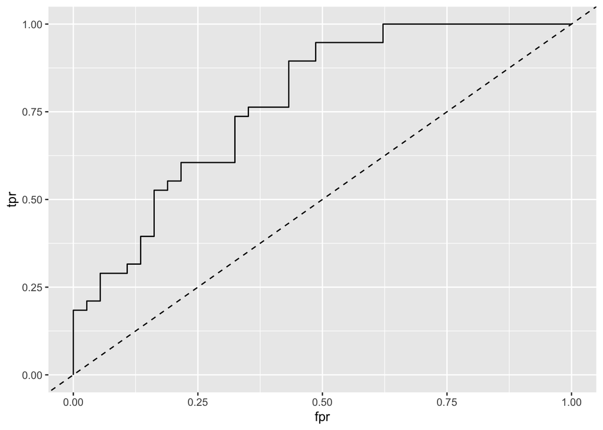

## model= ridge filter= 0.05 outcome= hCG clin feat= age

|  | Accuracy | Sensitivity | Specificity | AUC |
| --- | --- | --- | --- | --- |
| metric.mean.df | 0.693 | 0.763 | 0.622 | 0.792 |
| metric.quantiles | (0.693-0.693) | (0.763-0.763) | (0.622-0.622) | (0.792-0.792) |

|  | Negative-reference | Positive-reference |
| --- | --- | --- |
| Negative-prediction | 23 | 9 |
| Positive-prediction | 14 | 29 |

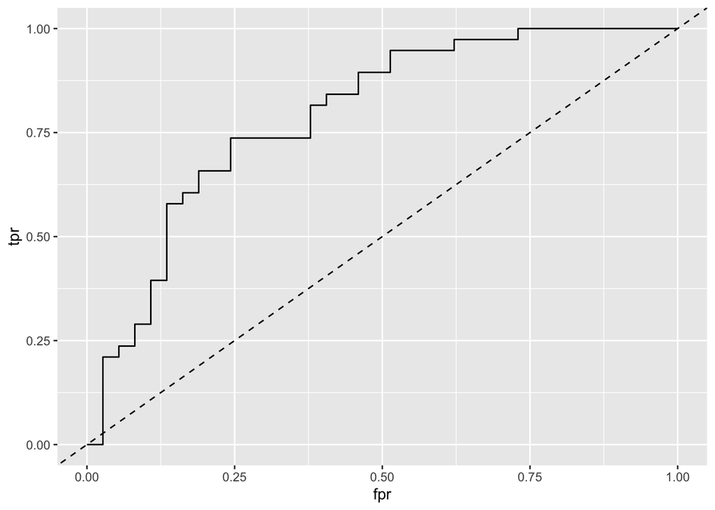

## model= ridge filter= 0.05 outcome= hCG clin feat= g1+g2+g3

|  | Accuracy | Sensitivity | Specificity | AUC |
| --- | --- | --- | --- | --- |
| metric.mean.df | 0.72 | 0.789 | 0.649 | 0.763 |
| metric.quantiles | (0.72-0.72) | (0.789-0.789) | (0.649-0.649) | (0.763-0.763) |

|  | Negative-reference | Positive-reference |
| --- | --- | --- |
| Negative-prediction | 24 | 8 |
| Positive-prediction | 13 | 30 |

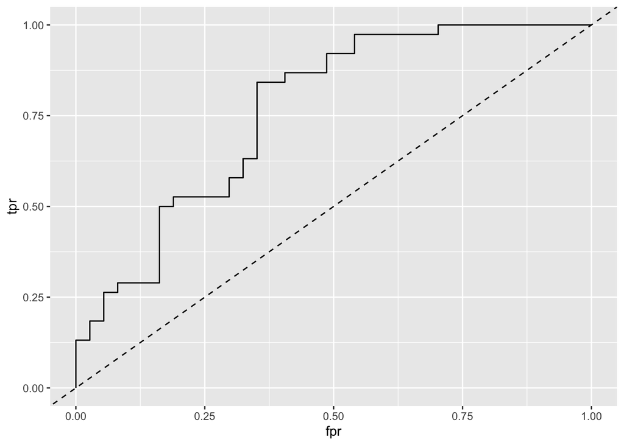

## model= ridge filter= 0.05 outcome= hCG clin feat= g1+g2+g3+age

|  | Accuracy | Sensitivity | Specificity | AUC |
| --- | --- | --- | --- | --- |
| metric.mean.df | 0.707 | 0.763 | 0.649 | 0.781 |
| metric.quantiles | (0.707-0.707) | (0.763-0.763) | (0.649-0.649) | (0.781-0.781) |

|  | Negative-reference | Positive-reference |
| --- | --- | --- |
| Negative-prediction | 24 | 9 |
| Positive-prediction | 13 | 29 |

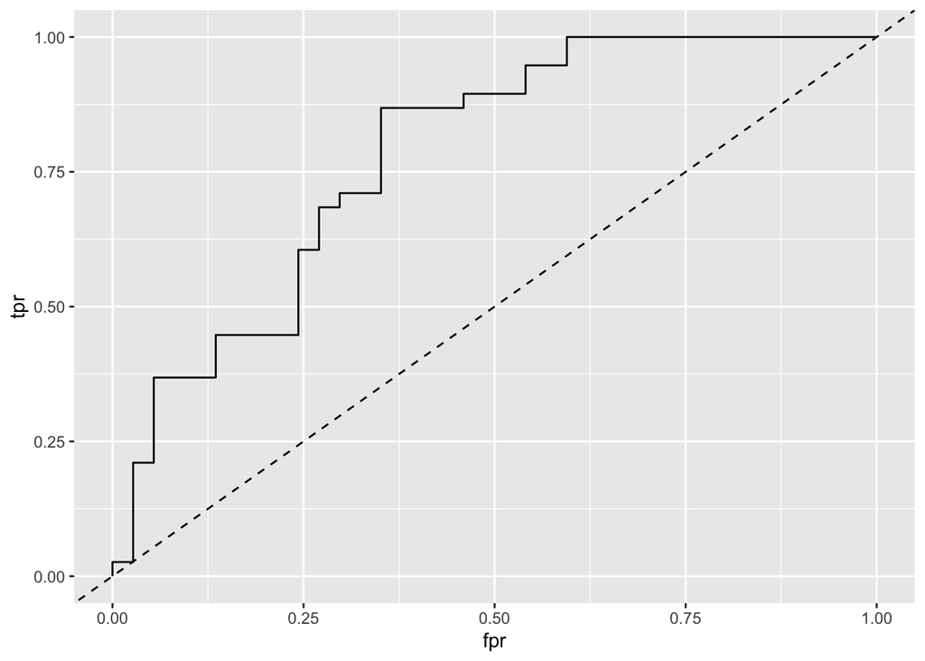

## model= ridge filter= 0.05 outcome= hCG clin feat= g3

|  | Accuracy | Sensitivity | Specificity | AUC |
| --- | --- | --- | --- | --- |
| metric.mean.df | 0.667 | 0.711 | 0.622 | 0.775 |
| metric.quantiles | (0.667-0.667) | (0.711-0.711) | (0.622-0.622) | (0.775-0.775) |

|  | Negative-reference | Positive-reference |
| --- | --- | --- |
| Negative-prediction | 23 | 11 |
| Positive-prediction | 14 | 27 |

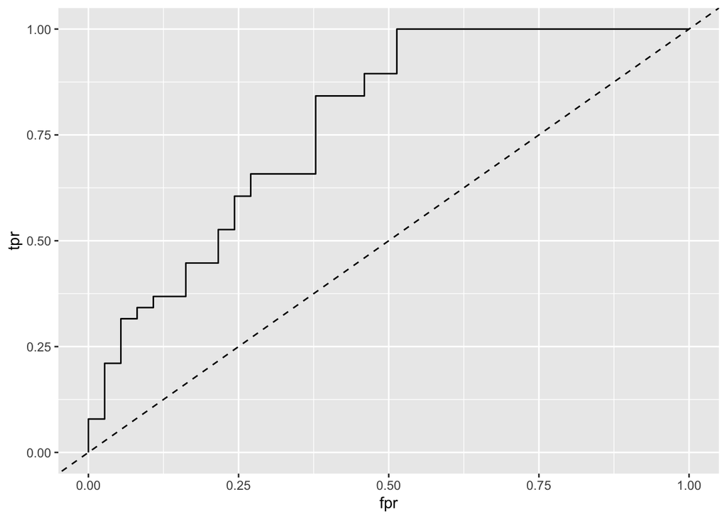

## model= ridge filter= 0.05 outcome= hCG clin feat= g3+age

|  | Accuracy | Sensitivity | Specificity | AUC |
| --- | --- | --- | --- | --- |
| metric.mean.df | 0.707 | 0.763 | 0.649 | 0.781 |
| metric.quantiles | (0.707-0.707) | (0.763-0.763) | (0.649-0.649) | (0.781-0.781) |

|  | Negative-reference | Positive-reference |
| --- | --- | --- |
| Negative-prediction | 24 | 9 |
| Positive-prediction | 13 | 29 |

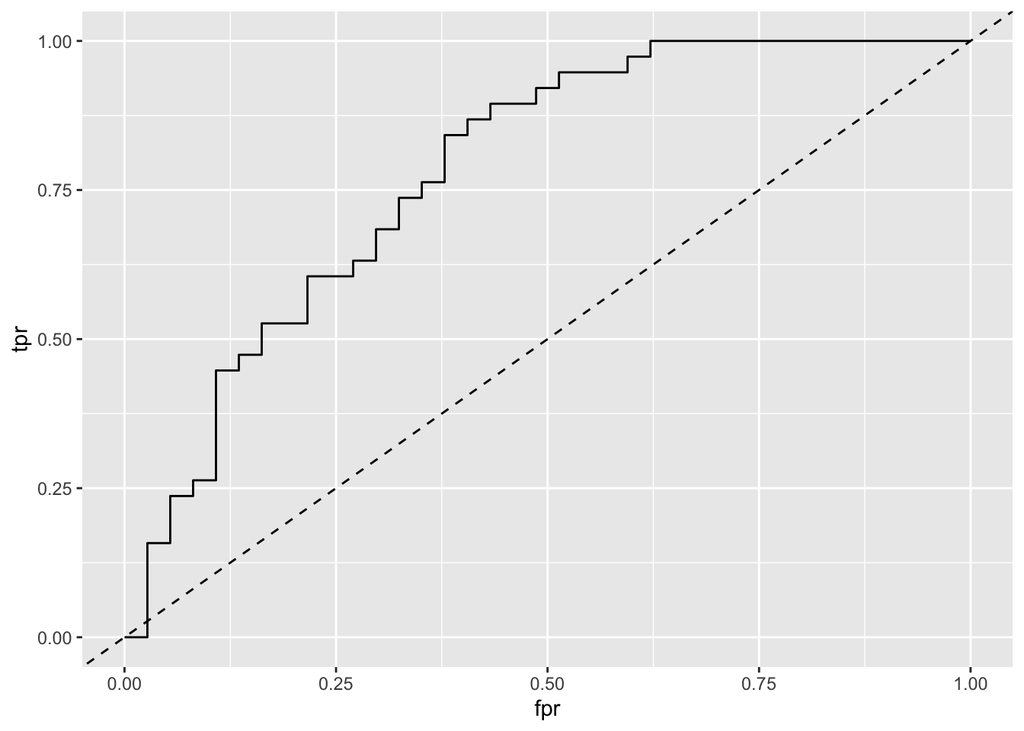

## model= ridge filter= 0.1 outcome= hCG clin feat= none

|  | Accuracy | Sensitivity | Specificity | AUC |
| --- | --- | --- | --- | --- |
| metric.mean.df | 0.733 | 0.737 | 0.73 | 0.835 |
| metric.quantiles | (0.733-0.733) | (0.737-0.737) | (0.73-0.73) | (0.835-0.835) |

|  | Negative-reference | Positive-reference |
| --- | --- | --- |
| Negative-prediction | 27 | 10 |
| Positive-prediction | 10 | 28 |

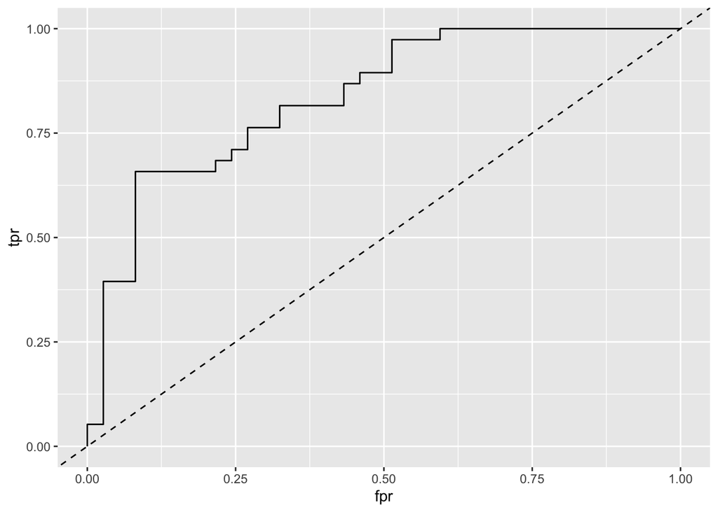

## model= ridge filter= 0.1 outcome= hCG clin feat= age

|  | Accuracy | Sensitivity | Specificity | AUC |
| --- | --- | --- | --- | --- |
| metric.mean.df | 0.707 | 0.737 | 0.676 | 0.826 |
| metric.quantiles | (0.707-0.707) | (0.737-0.737) | (0.676-0.676) | (0.826-0.826) |

|  | Negative-reference | Positive-reference |
| --- | --- | --- |
| Negative-prediction | 25 | 10 |
| Positive-prediction | 12 | 28 |

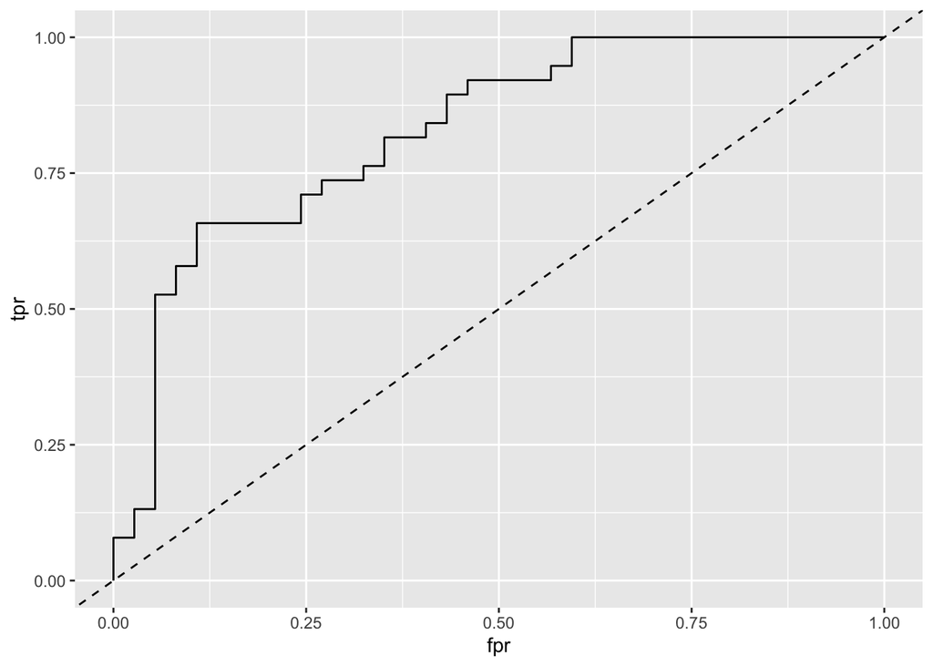

## model= ridge filter= 0.1 outcome= hCG clin feat= g1+g2+g3

|  | Accuracy | Sensitivity | Specificity | AUC |
| --- | --- | --- | --- | --- |
| metric.mean.df | 0.76 | 0.763 | 0.757 | 0.84 |
| metric.quantiles | (0.76-0.76) | (0.763-0.763) | (0.757-0.757) | (0.84-0.84) |

|  | Negative-reference | Positive-reference |
| --- | --- | --- |
| Negative-prediction | 28 | 9 |
| Positive-prediction | 9 | 29 |

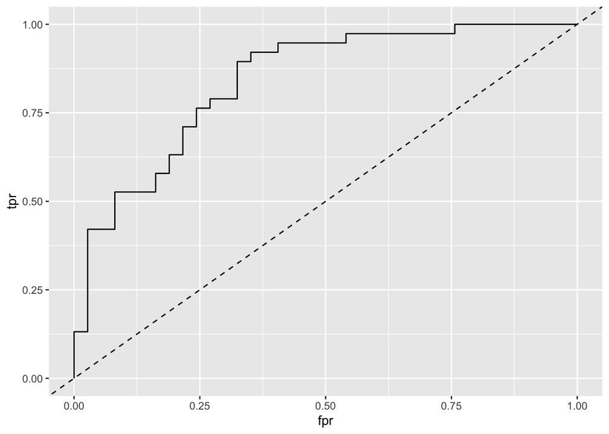

## model= ridge filter= 0.1 outcome= hCG clin feat= g1+g2+g3+age

|  | Accuracy | Sensitivity | Specificity | AUC |
| --- | --- | --- | --- | --- |
| metric.mean.df | 0.747 | 0.763 | 0.73 | 0.846 |
| metric.quantiles | (0.747-0.747) | (0.763-0.763) | (0.73-0.73) | (0.846-0.846) |

|  | Negative-reference | Positive-reference |
| --- | --- | --- |
| Negative-prediction | 27 | 9 |
| Positive-prediction | 10 | 29 |

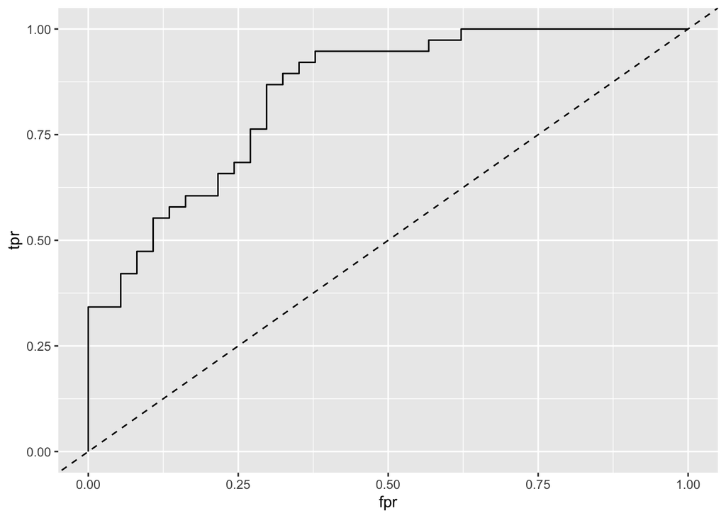

## model= ridge filter= 0.1 outcome= hCG clin feat= g3

|  | Accuracy | Sensitivity | Specificity | AUC |
| --- | --- | --- | --- | --- |
| metric.mean.df | 0.733 | 0.737 | 0.73 | 0.831 |
| metric.quantiles | (0.733-0.733) | (0.737-0.737) | (0.73-0.73) | (0.831-0.831) |

|  | Negative-reference | Positive-reference |
| --- | --- | --- |
| Negative-prediction | 27 | 10 |
| Positive-prediction | 10 | 28 |

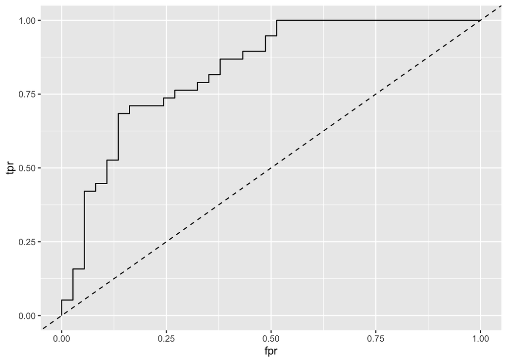

## model= ridge filter= 0.1 outcome= hCG clin feat= g3+age

|  | Accuracy | Sensitivity | Specificity | AUC |
| --- | --- | --- | --- | --- |
| metric.mean.df | 0.733 | 0.711 | 0.757 | 0.837 |
| metric.quantiles | (0.733-0.733) | (0.711-0.711) | (0.757-0.757) | (0.837-0.837) |

|  | Negative-reference | Positive-reference |
| --- | --- | --- |
| Negative-prediction | 28 | 11 |
| Positive-prediction | 9 | 27 |

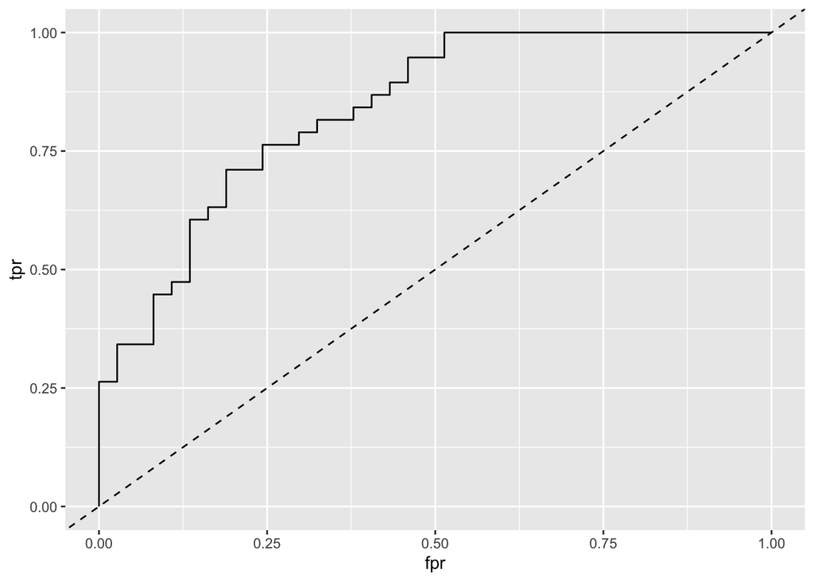